# OpenGWASDB Hybrid Layout — Hybrid vs Dense-of-union

Heterogeneous consortia (BMI · CAD · LDL) · one shared panel · reference-completed

Published

July 10, 2026

## Overview

Three **independent consortium GWAS**, each imputed to a *different* panel yet genome-wide with a large shared common core — the regime the **Hybrid Layout** (ADR 0026) targets:

| Study | Trait |
| --- | --- |
| ieu-a-2 | Body mass index (GIANT) |
| ieu-a-7 | Coronary heart disease (CARDIoGRAMplusC4D) |
| ieu-a-300 | LDL cholesterol |

Both layouts are built from the **same three GWAS-VCFs** against the **same EUR reference panel**, and both are reference-completed:

- **Hybrid** — a Dense Component on the panel (imputable) + a Ragged Overflow of each study’s off-panel observed variants.
- **Dense-of-union** — a single dense matrix over the *whole* observed union (ADR 0022’s rule applied to this regime), for comparison.

This report compares their storage and query latency, then validates the completed Hybrid store with positive-control **imputed-only MR** and a regional imputation plot.

| Property | Value |
| --- | --- |
| Analyses (GWAS) | 3 |
| Shared variant table (panel ∪ off-panel) | 10,394,488 |
| On-panel (Dense Component rows) | 9,847,807 |
| Off-panel (Ragged Overflow variants) | 546,681 |
| Reference assembly | GRCh38 |

> **All four stores validate** (observed-only and reference-completed, both layouts).

## Storage: Hybrid vs Dense-of-union

[output not shown]

The off-panel tail is **5%** of the shared variant table (546,681 of 10,394,488 variants). The Hybrid store keeps those raggedly (a `variant_index` per observed cell) and never imputes them, so its dense matrix — and therefore its dense variant axis, tabix index and ALID mmap — spans only the 9,847,807 imputable panel variants, versus all 10,394,488 in the Dense-of-union store.

## Query performance

Median of repeated calls after one warm-up, on the reference-completed stores.

| Pattern | Hybrid | Dense-of-union | What it reads |
| --- | --- | --- | --- |
| bulk | 2.78 s | 2.49 s | One analysis, all variants (`analysis`) |
| phewas | 7.7 ms | 0.7 ms | One (panel) variant × all analyses (`phewas`) |
| regional | 14.72 s | 3.6 ms | All associations in a 1 Mb window (`range_phewas`) |
| tophits | 2.6 ms | 1.7 ms | Genome-wide significant index read (`top_hits`) |
| random_lookup | 418.4 ms | 32.0 ms | 100 variants × analyses (`lookup`) |

## MR validation: imputed-only positive controls

Two positive-control **IVW Mendelian randomization** runs straight off the store. For the completed Hybrid store each uses **only imputed instruments** — the exposure top hit and both exposure/outcome lookup cells must be imputed by the Dense Component’s completion — compared against the observed-only estimate.

| Exposure → Outcome | Observed IVW β | Imputed-only IVW β | Imputed p |
| --- | --- | --- | --- |
| LDL cholesterol → CAD | 0.376 (n=74) | 0.236 (n=14) | 1.2e-21 |
| BMI → CAD | 0.407 (n=83) | 0.415 (n=6) | 1.3e-03 |

The imputed-only estimates are **positive** for LDL cholesterol → CAD, BMI → CAD — the expected direction, and consistent with the observed-only estimate. The completed Hybrid store’s imputed dense cells reproduce the causal signal.

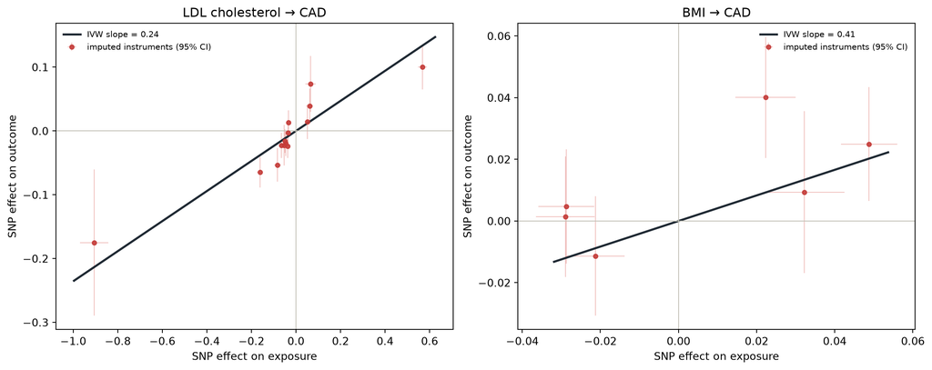

Imputed-only per-instrument effects (completed Hybrid store): exposure (x) vs outcome (y), 95% CIs, IVW slope.

## Regional imputation sanity check

A 1 Mb window centred on the strongest imputed LDL top hit in the completed Hybrid store; every association returned for the window, imputed highlighted against observed.

- **Analysis**: `ieu-a-300` (LDL cholesterol)
- **Region**: chr19:44,409,976-45,409,976 (centre z=58.03)
- **Associations plotted**: 3,962 total; 591 observed, 3,371 imputed.

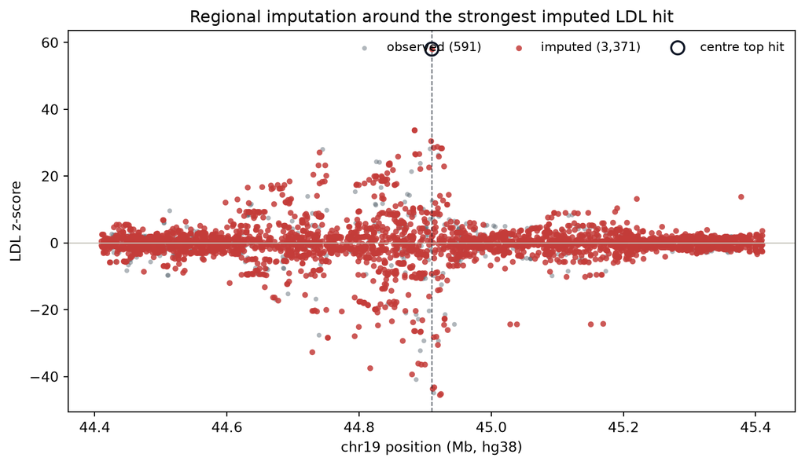

One megabase around the strongest imputed LDL top hit. Imputed associations highlighted in red.

## Provenance

- Data: `opengwasdb_hybrid_ieua_benchmark.json` (from `benchmarks/benchmark_hybrid_ieua.py`).
- Layout: Hybrid (ADR 0026) — Dense Component (panel) + Ragged Overflow (off-panel observed), reference completion targets the Dense Component only.
- MR is a demonstration/validation of the query layer, not a definitive epidemiological estimate (distance-based pruning in place of LD clumping).